## **POMO3**

O POMO3 continua a surpreender ao fechar o dia com um aumento de 3,25% em relação ao dia anterior, alcançando um novo recorde de R$ 7,31. Essa performance é ainda mais impressionante quando consideramos que a abertura da semana foi também favorável ao ativo, com uma valorização de 2,96% na semana.A verdadeira história por trás desse desempenho é o destaque no intraday que ocorreu às 14:26:00s, onde houve um ponto de negociação extremamente intenso, representando 14,98% do total negociado no dia para o ativo. Isso gerou uma variação impressionante de 1,575% na cotação do ativo logo após esse momento.Essa intensidade nos movimentos é refletida também nas médias móveis, que indicam uma tendência alcista contínua desde o início da semana. Além disso, a análise dos dados de volume e variação nos mostra que o POMO3 está se consolidando como um ativo com forte potencial de crescimento.Com essa performance impressionante, é natural esperar que os investidores sejam atraídos para o POMO3, aumentando sua valorização e justificando as expectativas de curto prazo. Veja a seguir o gráfico do intraday com o destaque do outlier: as setas amarelas destacam o momento e o volume negociado no ponto de outlier. A linha violeta demonstra a tendência do preço antes e depois do destaque.

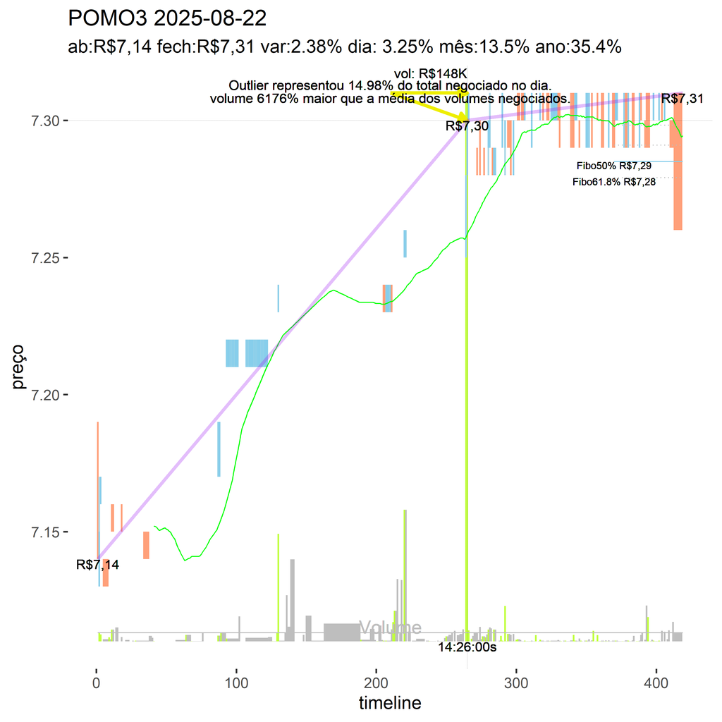

A seguir, desempenho do ativo ao longo do tempo:

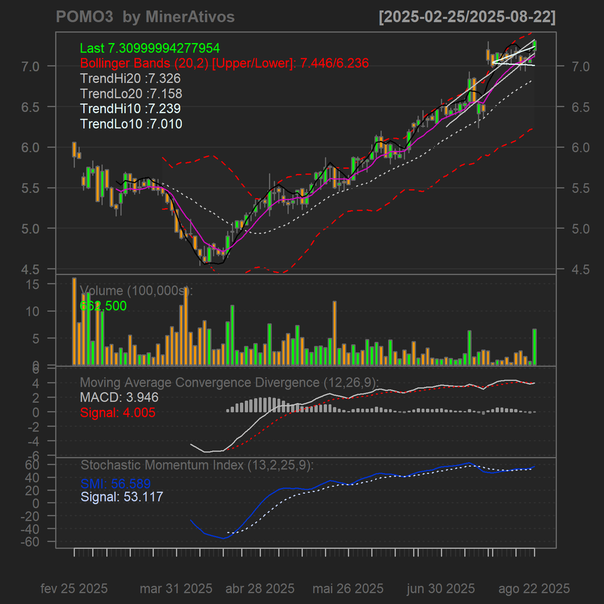

[figure not shown]

## **RAIZ4**

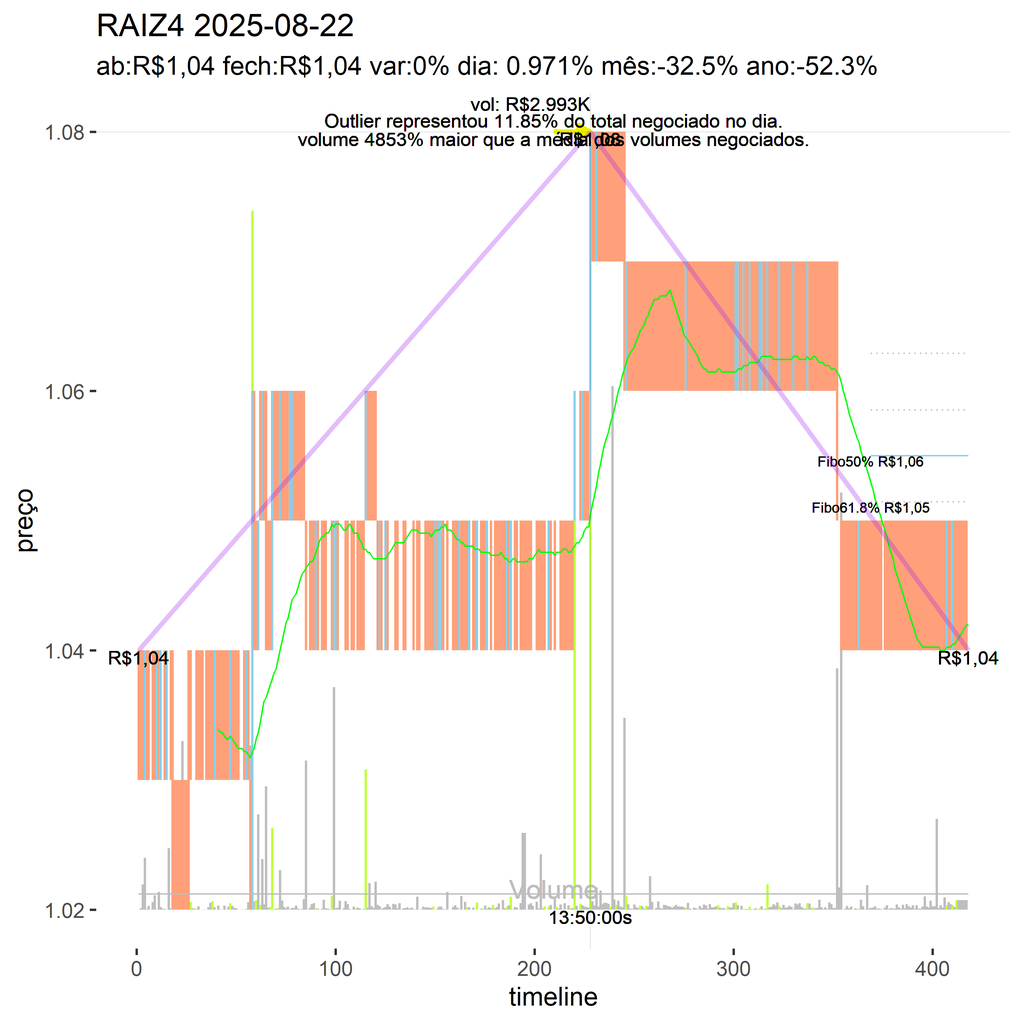

A seguir, desempenho do ativo ao longo do tempo:

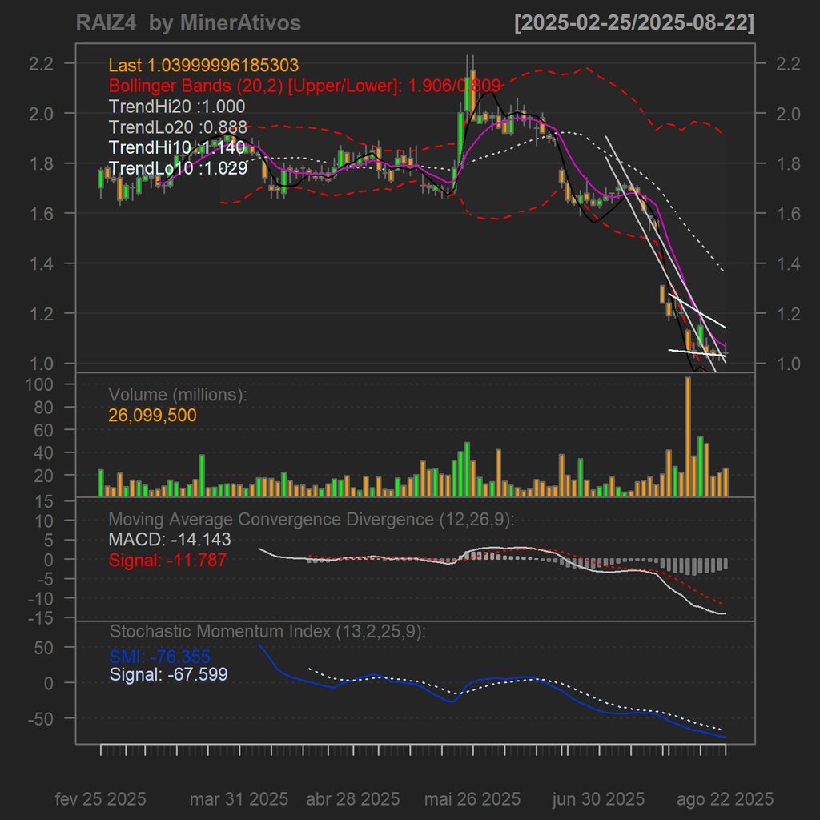

E assim concluímos nossa jornada diária pelos caminhos do mercado financeiro brasileiro. 📊💼 Espero que esses breves insights tenham contribuído e inspirado novas perspectivas sobre o fascinante universo do Ibovespa.

A conversa não termina aqui! 💬🌐 Convidamos todos vocês a compartilhar suas próprias análises, estratégias e pensamentos nos comentários. Afinal, é através do intercâmbio de ideias que todos nós prosperamos como investidores e membros desta comunidade vibrante.

Fiquem atentos para mais análises e discussões amanhã. Até lá, que seus investimentos sejam sólidos e suas decisões informadas. 🚀🔍 Juntos, vamos além dos números e construímos um entendimento mais profundo dos mercados!

#Ibovespa #AnáliseDiária #Investimentos #ComunidadeFinanceira

*Exoneração de responsabilidade*[^1]

[^1]: As informações e análises contidas neste material são de caráter meramente informativo e educacional, baseadas em dados estatísticos e análise técnica do mercado financeiro. Este material não constitui e não deve ser interpretado como uma recomendação de investimento, aconselhamento financeiro ou oferta de compra ou venda de quaisquer ativos financeiros. O autor deste material não se responsabiliza por quaisquer perdas ou danos decorrentes do uso das informações aqui apresentadas. O investimento em ações e outros ativos financeiros envolve riscos significativos, e o desempenho passado não garante resultados futuros. Cada investidor é responsável por suas próprias decisões de investimento, devendo buscar orientação de profissionais qualificados antes de tomar qualquer decisão. As análises e insights apresentados neste material refletem insights sistêmicos em um determinado momento e estão sujeitos a alterações sem aviso prévio. O autor não garante a precisão, integridade ou atualidade das informações aqui fornecidas, e não se responsabiliza por eventuais erros ou omissões. Ao utilizar este material, você concorda em isentar o autor de qualquer responsabilidade por quaisquer perdas ou danos, diretos ou indiretos, decorrentes do uso das informações aqui contidas.